# Bank Marketing - Term Deposit Classification Model

### (4) Generalized Linear Model (glmnet):

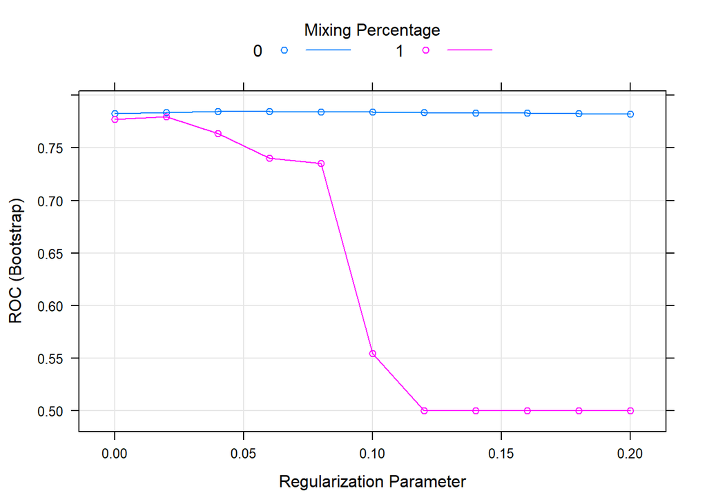

```r
if(!exists("model_glmnet")) {
  model_glmnet <- caret::train(
  y ~ ., train,
  metric = "ROC",
  method = "glmnet",
  tuneGrid = expand.grid(
    alpha = c(0,1),
    lambda = 10:0/50
  ),
  trControl = myControl
)
}
plot(model_glmnet)
```

### (5) glmnet with PCA preprocessing

[figure not shown]

```r
if(!exists("model_glmnet_pca")) {
  model_glmnet_pca <- train(
    y ~ ., train,
    metric = "ROC",
    method = "glmnet",
    tuneGrid = expand.grid(
      alpha = c(0,1),
      lambda = 10:0/50
    ),
    trControl = myControl,
    preProcess = c("zv", "nzv","center","scale","pca")
  )
}
plot(model_glmnet_pca)
```

### (6) glmnet with manual feature selection:

The step to manually select features are:

1. Run glm models on the dataset.
2. Exclude the features that the glm models consider having high P value.
3. Rerun glmnet models using the resulting features after step 2.

Steps 1 and 2 are not shown here. Only the results for step 3 is shown.

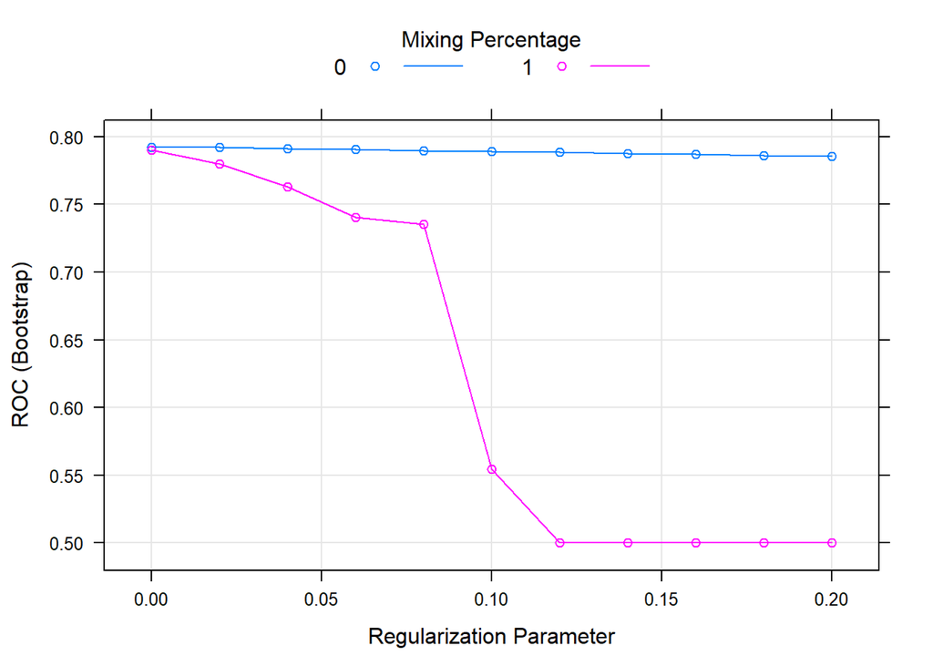

```r
if(!exists("model_glmnet_mannual_feature_selection")) {
  model_glmnet_mannual_feature_selection <- caret::train(
  y ~ .-loan-education-marital-housing-age_group-job-emp.var.rate.cat-previous-default, train,
  metric = "ROC",
  method = "glmnet",
  tuneGrid = expand.grid(
    alpha = c(0,1),
    lambda = 10:0/50
  ),
  trControl = myControl
)
}
plot(model_glmnet_mannual_feature_selection)
```

### (7) Random Forest

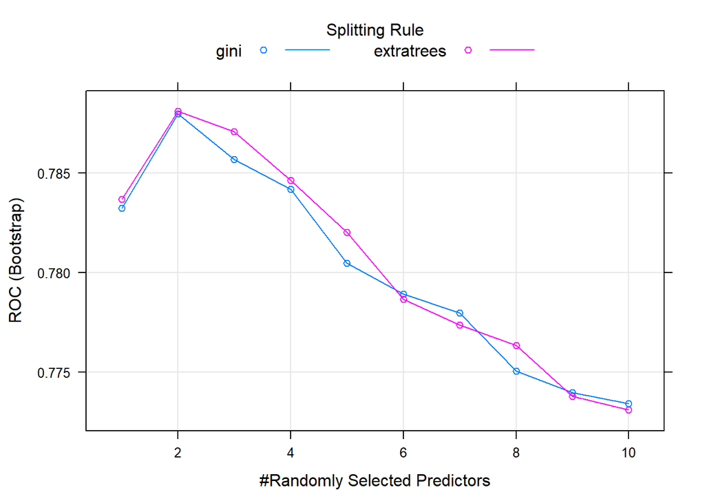

```r
if(!exists("model_rf")) {
  model_rf <- caret::train(
  y ~ ., train,
  metric = "ROC",
  method = "ranger",
  importance = 'impurity',
  trControl = myControl,
  tuneGrid = expand.grid(
    mtry = seq(1,10,1),
    splitrule = c("gini","extratrees"),
    min.node.size = c(1)
  )
)
}
plot(model_rf)
```

### (8) Model stacking

As a experiement, what if we stack two levels of models? The idea is as follows:

1. Train two models in the 1st level: one using features only related to client’s personal information; and one using only micro-economic features.
2. Use the outcome from level 1 and train another model.

This is “model stacking”. In order to prevent overfitting, we further split the training data into two sets. The first set is used for level 1 training and the second is used for level 2 traning.

```r
# Model stacking
# Two level of modelling; need to use two different datasets for two models in order to avoid overfit
split_train = createDataPartition(train$y, times = 1, p=0.5, list = F)
train_level1 = train[split_train,]
train_level2 = train[-split_train,]
folds_level1 <- createFolds(train_level1$y, k = 5)
level1_control <- trainControl(
  summaryFunction = twoClassSummary,
  classProbs = TRUE,
  savePredictions = "final",
  index = folds_level1,
  verboseIter = F
)

formula_personal = y~job+marital+education+default+housing+contact+month+day_of_week+
                    previous+poutcome+age_group+pdays_cat+campaign_cat
formula_macro = y~emp.var.rate.cat+cons.conf.idx.cat+cons.price.idx.cat+euribor3m.cat+nr.employed.cat
model_personal <- caret::train(
  formula_personal, train_level1,
  metric = "ROC",
  method = "ranger",
  trControl = level1_control
)
model_macro <- caret::train(
  formula_macro, train_level1,
  metric = "ROC",
  method = "glmnet",
  trControl = level1_control
)
resamp = resamples(list(personal=model_personal,macro=model_macro))
# Show level 1 performance
summary(resamp,metric="ROC")
```

```
##
## Call:
## summary.resamples(object = resamp, metric = "ROC")
##
## Models: personal, macro
## Number of resamples: 5
##
## ROC
##               Min.   1st Qu.    Median      Mean   3rd Qu.      Max. NA's
## personal 0.7261480 0.7271372 0.7365061 0.7343658 0.7366359 0.7454017    0
## macro    0.7664619 0.7726626 0.7779067 0.7761053 0.7786244 0.7848710    0
```

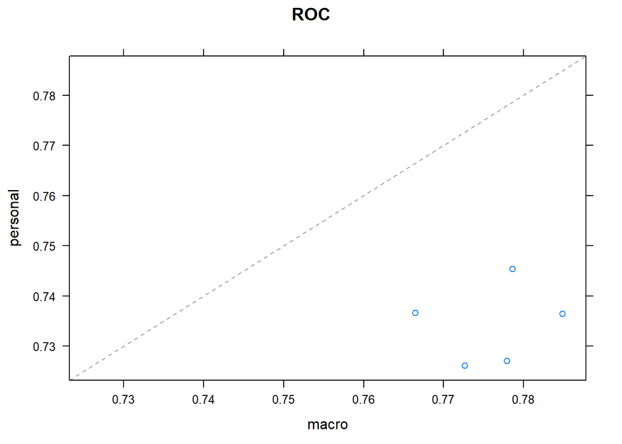

```r
xyplot(resamp)
```

However, as the “ROC” plots have shown, the level 1 predictions (“personal” vs “macro”) are not that uncorrelated, a hint that the stacking models may not perform exceptionally well. The following code documents the training of level 2 models.

```r
train_level2[["personal_pred"]] = predict(model_personal, train_level2, type = "prob")[,2]
train_level2[["macro_pred"]] = predict(model_macro, train_level2, type = "prob")[,2]
train_level2 = select(train_level2,-y,y)
folds_level2 <- createFolds(train_level2$y, k = 5)
level2_control <- trainControl(
  summaryFunction = twoClassSummary,
  classProbs = TRUE,
  savePredictions = "final",
  index = folds_level2,
  verboseIter = F
)

model_stack <- caret::train(
  y~personal_pred*macro_pred, train_level2,
  metric = "ROC",
  method = "glm",
  trControl = level2_control
)
summary(model_stack)
```

```
##
## Call:
## NULL
##
## Deviance Residuals:
##     Min       1Q   Median       3Q      Max
## -1.7348  -0.3805  -0.3351  -0.2878   2.5921
##
## Coefficients:
##                            Estimate Std. Error z value Pr(>|z|)
## (Intercept)                 -3.8981     0.1422 -27.407  < 2e-16 ***
## personal_pred                8.4402     1.1079   7.618 2.57e-14 ***
## macro_pred                   5.7748     0.5103  11.317  < 2e-16 ***
## `personal_pred:macro_pred`  -9.1395     2.7042  -3.380 0.000725 ***
## ---
## Signif. codes:  0 '***' 0.001 '**' 0.01 '*' 0.05 '.' 0.1 ' ' 1
##
## (Dispersion parameter for binomial family taken to be 1)
##
##     Null deviance: 3624.7  on 5147  degrees of freedom
## Residual deviance: 2864.2  on 5144  degrees of freedom
## AIC: 2872.2
##
## Number of Fisher Scoring iterations: 5
```

```r
model_stack
```

```
## Generalized Linear Model
##
## 5148 samples
##    2 predictor
##    2 classes: 'no', 'yes'
##
## No pre-processing
## Resampling: Bootstrapped (5 reps)
## Summary of sample sizes: 1030, 1030, 1029, 1030, 1029
## Resampling results:
##
##   ROC       Sens       Spec
##   0.787877  0.9761935  0.2659483
```

We can visuallize what the level 1 predictions look like. Note that the predictions are probabilities.

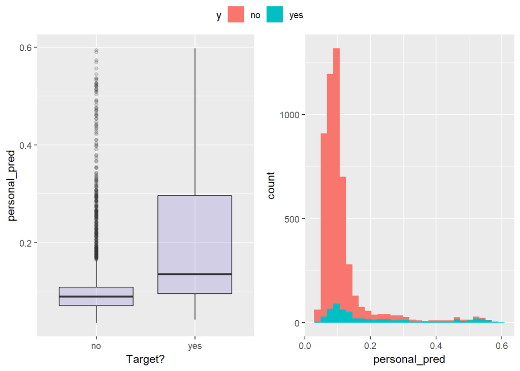

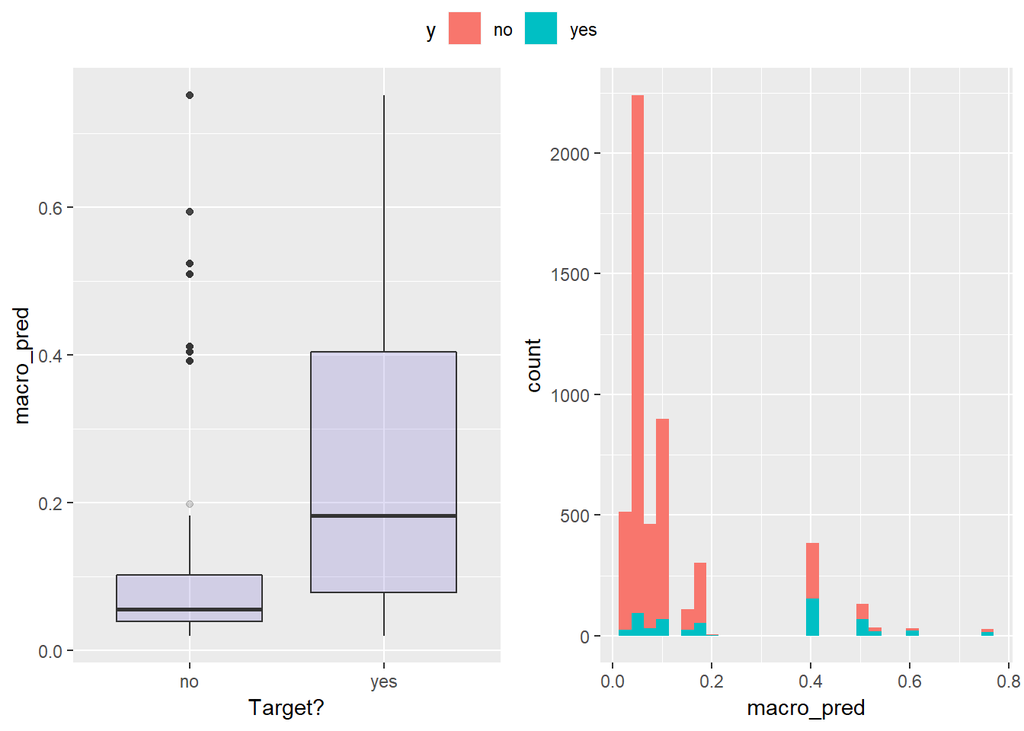

```r
# What the two level 1 prediction look like?
for (i in (length(train_level2)-3):(length(train_level2)-1)) {
    col = colnames(train_level2)[i];
    if(!is.numeric(train_level2[,i])) next
    p1 = ggplot(train_level2, aes(x=y, y=train_level2[,i])) +
      geom_boxplot(fill="slateblue", alpha=0.2) +
      xlab("Target?") + ylab(col)
    p2 = ggplot(train_level2, aes(x=train_level2[,col],fill=y)) + geom_histogram() + xlab(col)
    p3 = ggarrange(p1, p2, ncol = 2, nrow = 1, common.legend = TRUE)
    print(p3)
  }
```

## VI. Evaluation

To evaluate which model performs the best, we can create a dot plot to see which model had the best ROC.

Note that the resampling index for the stacked models are actually different than the other models. As previously mentioned, the training set was further divided into two partts, used in level 1 and level 2 training accordingly. Thus the performance of the stacking models is not a direct comparison with the other models.

```r
model_list = list(rf=model_rf,
                  glmnet=model_glmnet,
                  glmnet_pca=model_glmnet_pca,
                  glmnet_manual_feature=model_glmnet_mannual_feature_selection,
                  rpart=model_rpart,
                  nb=model_nb,
                  glm_stepAIC=model_glm_stepAIC,
                  stack=model_stack
                  )
resamps <- resamples(model_list)
summary(resamps, metric = "ROC")
```

```
##
## Call:
## summary.resamples(object = resamps, metric = "ROC")
##
## Models: rf, glmnet, glmnet_pca, glmnet_manual_feature, rpart, nb, glm_stepAIC, stack
## Number of resamples: 5
##
## ROC
##                            Min.   1st Qu.    Median      Mean   3rd Qu.
## rf                    0.7830782 0.7884011 0.7884404 0.7881015 0.7894941
## glmnet                0.7783449 0.7815763 0.7856720 0.7844177 0.7860189
## glmnet_pca            0.7706195 0.7729977 0.7737654 0.7766015 0.7810145
## glmnet_manual_feature 0.7900467 0.7906018 0.7913797 0.7920378 0.7928310
## rpart                 0.7530987 0.7577725 0.7586599 0.7578677 0.7589436
## nb                    0.7426215 0.7475961 0.7501364 0.7492727 0.7527896
## glm_stepAIC           0.7737530 0.7750468 0.7762397 0.7788798 0.7785569
## stack                 0.7817188 0.7869446 0.7873404 0.7878770 0.7897569
##                            Max. NA's
## rf                    0.7910937    0
## glmnet                0.7904763    0
## glmnet_pca            0.7846104    0
## glmnet_manual_feature 0.7953299    0
## rpart                 0.7608640    0
## nb                    0.7532199    0
## glm_stepAIC           0.7908023    0
## stack                 0.7936245    0
```

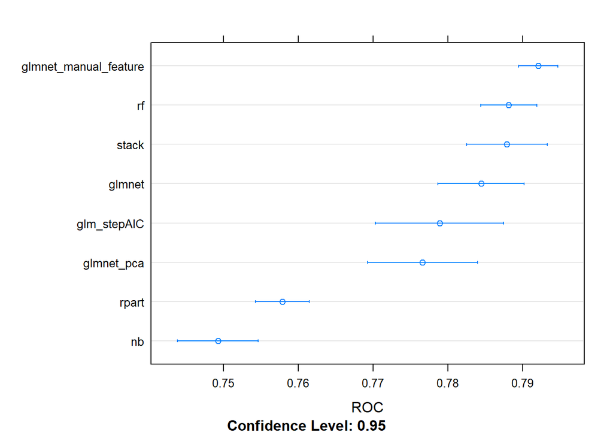

```r
dotplot(resamps, metric = "ROC")
```

With this, we can see that glmnet with manual feature selection is the best performer—glmnet is simple yet powerful.

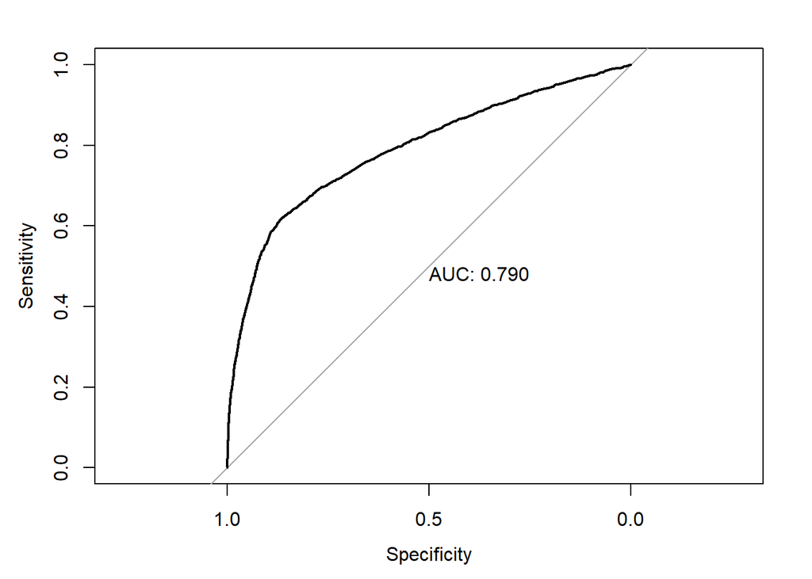

```r
best_model = model_glmnet_mannual_feature_selection
# Evaluate on the test set
p = predict(best_model, test, type = "prob")[,2]
plot.roc(test$y,p,print.auc=T)
```

To further evaluate the model, we can take a look at the return on investment (ROI) for this bank marketing campaign. The idea was inspired by GitHub user kurakura0916 and their own attempt at this same dataset. If we assume that each call costs $10 to make, but each customer who converts is worth $20, ROI is calculated as follows:

**ROI = 20 * # of sales - 10 * # of calls**

The output of the models are probabilities. At what threshold of the probabilities can we yield maximum ROI? The following plots illustrate ROI vs. threshold:

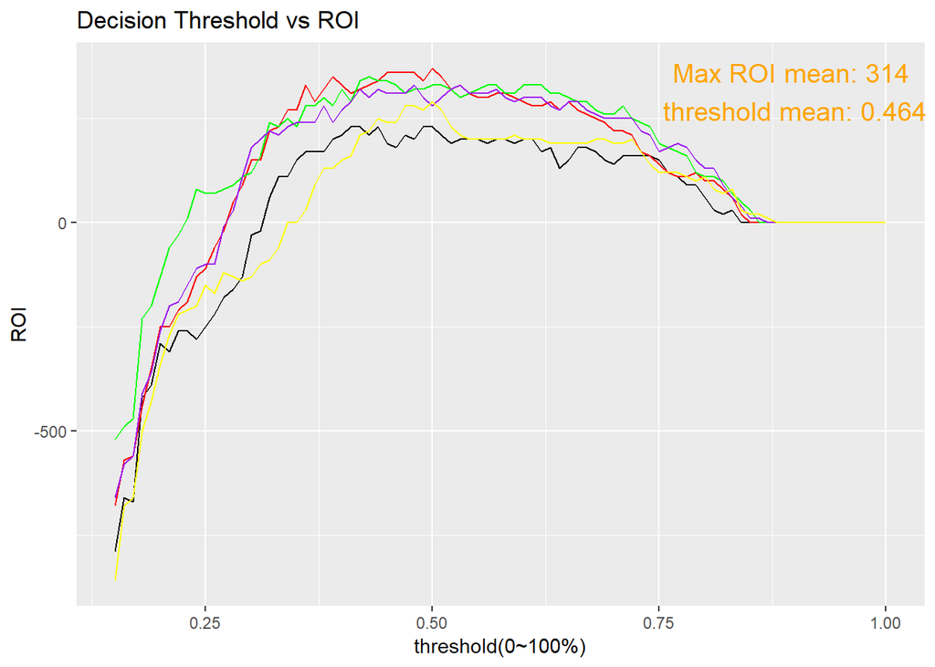

```r
# Use cross validation to determine the threshold inorder to generate greatest ROI
# The idea is inspired by: https://github.com/kurakura0916/bank_marketing
# ROI = Number of Acquired Customer * 20 - 10 * Number of Calls
library(rlist)
roi_list = list()
max_roi_vec = c()
max_thres_vec = c()
for (fold in folds) {
  cvdata = train[fold,]
  p = predict(best_model, cvdata, type = "prob")[,2]
  roi = data.frame(thres=c(),roi=c())
  for(thres in seq(0.15,1,0.01)) {
    pred = ifelse(p>thres,"yes","no")
    cost = 10 * sum(pred=="yes")
    gain = 20 * sum(cvdata$y=="yes" & pred=="yes")
    roi<-rbind(roi, data.frame(thres=thres, roi=gain-cost))
  }
  roi_list = list.append(roi_list,roi)
  max_roi_vec = c(max_roi_vec,max(roi$roi))
  max_thres_vec = c(max_thres_vec,roi$thres[which.max(roi$roi)])
}
max_roi_mean = mean(max_roi_vec)
max_thres_mean = mean(max_thres_vec)
ggplot(roi_list[[1]],aes(x=thres,y=roi)) +
  geom_line() +
  geom_line(data=roi_list[[2]],color="red") +
  geom_line(data=roi_list[[3]],color="green") +
  geom_line(data=roi_list[[4]],color="purple") +
  geom_line(data=roi_list[[5]],color="yellow") +
  labs(title ="Decision Threshold vs ROI", x = "threshold(0~100%)", y = "ROI") +
  annotate("text", x = 0.9, y = max_roi_mean,
           label = c(paste("Max ROI mean:",max_roi_mean,"\nthreshold mean:",max_thres_mean)) , color="orange", size=5 , angle=0)
```

```r
# On test set:
p = predict(best_model, test, type = "prob")[,2]
pred = ifelse(p>max_thres_mean,"yes","no")
cost = 10 * sum(pred=="yes")
gain = 20 * sum(test$y=="yes" & pred=="yes")
confusionMatrix(as.factor(ifelse(p>max_thres_mean,"yes","no")),test$y,mode="prec_recall")
```

```
## Confusion Matrix and Statistics
##
##           Reference
## Prediction    no   yes
##        no  26904  2597
##        yes   507   883
##
##                Accuracy : 0.8995
##                  95% CI : (0.8961, 0.9028)
##     No Information Rate : 0.8873
##     P-Value [Acc > NIR] : 3.293e-12
##
##                   Kappa : 0.3188
##  Mcnemar's Test P-Value : < 2.2e-16
##
##               Precision : 0.9120
##                  Recall : 0.9815
##                      F1 : 0.9455
##              Prevalence : 0.8873
##          Detection Rate : 0.8709
##    Detection Prevalence : 0.9550
##       Balanced Accuracy : 0.6176
##
##        'Positive' Class : no
##
```

Under the ROI foumular we have assumed, if we use predictive models, bank would make $3760. If the bank just simply calls everyone, the bank would make $-2.393110^{5}! The marketing campaign would lose money, which is the exact opposite effect that a marketing campaign should have.

Finally, for our own edification, we can also plot the importance of variables to see how our best model has ranked the attributes that were used to train it:

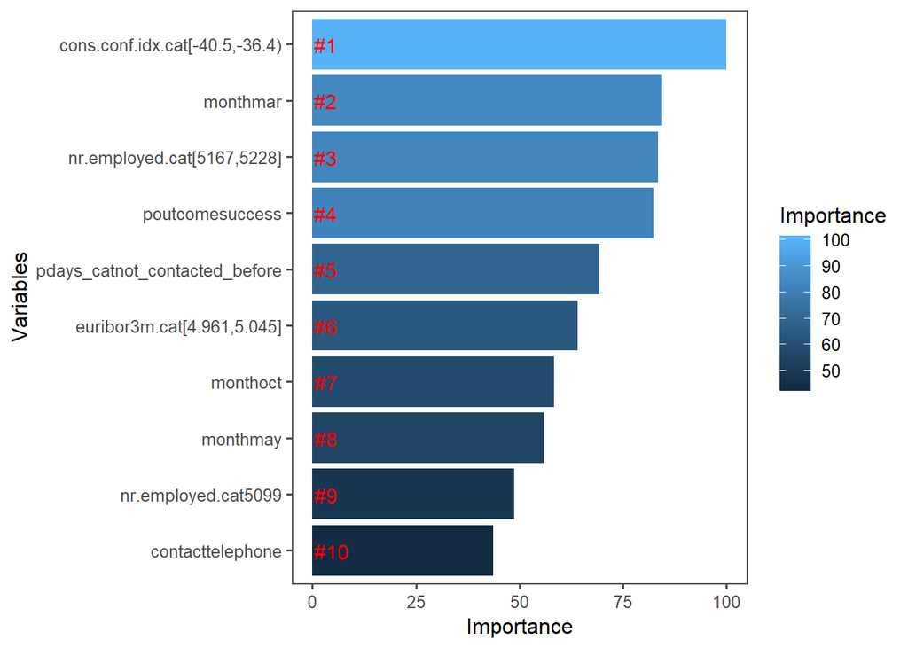

```r
library(ggthemes)
imp    <- varImp(best_model)$importance
varImportance <- data.frame(Variables = row.names(imp),
                            Importance = imp$Overall)
# Create a rank variable based on importance
rankImportance <- varImportance %>%
  mutate(Rank = paste0('#',dense_rank(desc(Importance))))
rankImportance = rankImportance[order(rankImportance$Importance,decreasing = T),]
rankImportance = rankImportance[1:10,]
# Use ggplot2 to visualize the relative importance of variables
ggplot(rankImportance, aes(x = reorder(Variables, Importance),
                           y = Importance, fill = Importance)) +
  geom_bar(stat='identity') +
  geom_text(aes(x = Variables, y = 0.5, label = Rank),
            hjust=0, vjust=0.55, size = 4, colour = 'red') +
  labs(x = 'Variables') +
  coord_flip() +
  theme_few()
```

## Deployment

An R Shiny dashboard was created and [uploaded to shinyapps](https://superstellar.shinyapps.io/BankMarketing-master/). It provides a more intuitive and visual look into the models that were built. A business analyst or marketing manager can take a look at the dashboard and draw their own conclusions about which factors are relevant and which are not. They can also explore the various models.

Additionally, recall the ROI formula we have previously asssumed: **ROI = 20 * # of sales - 10 * # of calls**

We have assumed the profit from each sale is $20 and the cost for each call is $10. What if the profit/cost ratio changes? This becomes a cost-volumn-profit analysis, which would be of great interest to those running a similar marketing campaign. An interactive ROI page has been included in the R Shiny dashboard where users can enter their own cost and profit numbers to see the maximum ROI under the assumptions they have provided. Interestingly, if the cost is sufficiently low, the model suggests a very low probability threshold, indicating that the bank may as well just call everyone.

Base on the merit and drawback of predictive modelling so far, if a bank would deploy such data product, it would need to:  
(1) Collect data on an on-going basis;  
(2) Collect more features and experiment if additional features could furthur drive up prediction accuracy;  
(3) Establish a way to evaluate source of data inconsistencies during data collection activities;  
(4) Rerun modelling on a timely manner, possiblely on a daily basis.  
(5) And last but not the least, conduct a thourough cost analysis to capture the true ROI formula.

## Conclusions

We can see that a classification model built for predicting whether a client will sign up for a term deposit has some real world application. In addition to being used to decide which clients to call, it can also be used in the planning phase. For example, if one could have a high ROI, it would be worth spending more money on the marketing campaign, but if the ROI is low, then it might be better use that marketing budget elsewhere.

An improvement that could be made in the future—especially with respect to ROI—is to consider that there was an attribute in the dataset for number of contacts made before a client converted. Each call has a certain cost associated with it, so a more sophisticated ROI analysis would include this. While our best-performing model didn’t include this attribute as an important attribute, it could be interesting to explore in the future.

Speaking of the best performing model, we determined that glmnet with manual feature selection was the best performer. This shows that manual feature selection/feature engineering, and thus humans making decisions, is still an important aspect of model creation. A simple and effective model provided an elegant solution to our problem.